# Tree based modeling, a Tidy approach

Claudia Tanaka (claudia.tanaka@al.infnet.edu.br)

17/06/2024

# 1 The setup

# 2 Load data

**DATA DICTIONARY:**

- **Survived** Survival (0 = No, 1 = Yes )
- **Pclass** Ticket class (1 = 1st, 2 = 2nd, 3 = 3rd )
- **Sex** Sex
- **Age** Age in years
- **SibSp** # of siblings / spouses aboard the Titanic
- **Parch** # of parents / children aboard the Titanic
- **Ticket** Ticket number
- **Fare** Passenger fare
- **Cabin** Cabin number
- **Embarked** Port of (Embarkation C = Cherbourg, Q = Queenstown, S = Southampton)

**NOTES:**

**Pclass**: A proxy for socio-economic status (SES):

1st = Upper  
2nd = Middle  
3rd = Lower

**Age**: Age is fractional if less than 1. If the age is estimated, is it in the form of xx.5

**SibSp**: The dataset defines family relations in this way…

Sibling = brother, sister, stepbrother, stepsister  
Spouse = husband, wife (mistresses and fiancés were ignored)

**Parch**: The dataset defines family relations in this way…

Parent = mother, father  
Child = daughter, son, stepdaughter, stepson

Some children travelled only with a nanny, therefore parch=0 for them.

```r
df0 <- read.csv("_datasets/train.csv") |> as_tibble() |>

  na.omit() |> # omits 177 observations missing Age
  mutate(AgeGroup = if_else(Age < 18, "children", "adults")) |>
  # select(-Age) |>

  rename(ParCh=Parch) |>
  mutate(Embarked = case_match(Embarked,
                               "C" ~ "Cherbourg",
                               "Q" ~ "Queenstown",
                               "S" ~ "Southampton",
                               .default=Embarked)) |>
  mutate(across(where(is.character), ~if_else(.x=="", NA, .x)),
         across(where(is.character), as.factor)) |>

  mutate(Pclass = factor(Pclass, ordered=T)) |>

  mutate(Survived = factor(as.logical(Survived), levels=c(TRUE, FALSE))) |>

  select(-Name, -Ticket, -Cabin)


str(df0)
```

```
## tibble [714 × 10] (S3: tbl_df/tbl/data.frame)
##  $ PassengerId: int [1:714] 1 2 3 4 5 7 8 9 10 11 ...
##  $ Survived   : Factor w/ 2 levels "TRUE","FALSE": 2 1 1 1 2 2 2 1 1 1 ...
##  $ Pclass     : Ord.factor w/ 3 levels "1"<"2"<"3": 3 1 3 1 3 1 3 3 2 3 ...
##  $ Sex        : Factor w/ 2 levels "female","male": 2 1 1 1 2 2 2 1 1 1 ...
##  $ Age        : num [1:714] 22 38 26 35 35 54 2 27 14 4 ...
##  $ SibSp      : int [1:714] 1 1 0 1 0 0 3 0 1 1 ...
##  $ ParCh      : int [1:714] 0 0 0 0 0 0 1 2 0 1 ...
##  $ Fare       : num [1:714] 7.25 71.28 7.92 53.1 8.05 ...
##  $ Embarked   : Factor w/ 3 levels "Cherbourg","Queenstown",..: 3 1 3 3 3 3 3 3 1 3 ...
##  $ AgeGroup   : Factor w/ 2 levels "adults","children": 1 1 1 1 1 1 2 1 2 2 ...
##  - attr(*, "na.action")= 'omit' Named int [1:177] 6 18 20 27 29 30 32 33 37 43 ...
##   ..- attr(*, "names")= chr [1:177] "6" "18" "20" "27" ...
```

```r
summarytools::dfSummary(df0, style="multiline",
                        plain.ascii=F, graph.col=F, valid.col=F) |>
  knitr::kable()
```

| No | Variable | Stats / Values | Freqs (% of Valid) | Missing |
| --- | --- | --- | --- | --- |
| 1 | PassengerId [integer] | Mean (sd) : 448.6 (259.1) min < med < max: 1 < 445 < 891 IQR (CV) : 455.5 (0.6) | 714 distinct values | 0 (0.0%) |
| 2 | Survived [factor] | 1. TRUE 2. FALSE | \290 (40.6%) \424 (59.4%) | 0 (0.0%) |
| 3 | Pclass [ordered, factor] | 1. 1 2. 2 3. 3 | \186 (26.1%) \173 (24.2%) \355 (49.7%) | 0 (0.0%) |
| 4 | Sex [factor] | 1. female 2. male | \261 (36.6%) \453 (63.4%) | 0 (0.0%) |
| 5 | Age [numeric] | Mean (sd) : 29.7 (14.5) min < med < max: 0.4 < 28 < 80 IQR (CV) : 17.9 (0.5) | 88 distinct values | 0 (0.0%) |
| 6 | SibSp [integer] | Mean (sd) : 0.5 (0.9) min < med < max: 0 < 0 < 5 IQR (CV) : 1 (1.8) | 0 : 471 (66.0%) 1 : 183 (25.6%) 2 : 25 ( 3.5%) 3 : 12 ( 1.7%) 4 : 18 ( 2.5%) 5 : 5 ( 0.7%) | 0 (0.0%) |
| 7 | ParCh [integer] | Mean (sd) : 0.4 (0.9) min < med < max: 0 < 0 < 6 IQR (CV) : 1 (2) | 0 : 521 (73.0%) 1 : 110 (15.4%) 2 : 68 ( 9.5%) 3 : 5 ( 0.7%) 4 : 4 ( 0.6%) 5 : 5 ( 0.7%) 6 : 1 ( 0.1%) | 0 (0.0%) |
| 8 | Fare [numeric] | Mean (sd) : 34.7 (52.9) min < med < max: 0 < 15.7 < 512.3 IQR (CV) : 25.3 (1.5) | 220 distinct values | 0 (0.0%) |
| 9 | Embarked [factor] | 1. Cherbourg 2. Queenstown 3. Southampton | \130 (18.3%) 28 ( 3.9%) \554 (77.8%) | 2 (0.3%) |
| 10 | AgeGroup [factor] | 1. adults 2. children | \601 (84.2%) \113 (15.8%) | 0 (0.0%) |

# 3 EDA

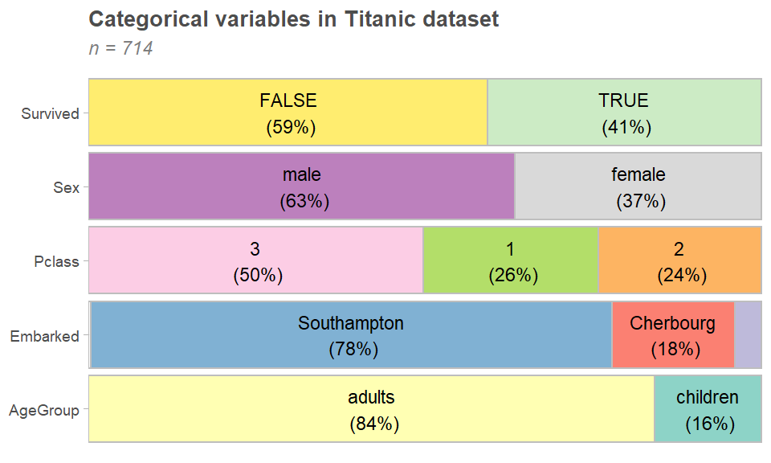

```r
df0 |> select(is.factor) |>
  mutate(across(everything(), as.character)) |>
  pivot_longer(dplyr::everything(), values_to="class", names_to="variable") |>
  summarise(value=n(), .by=c(variable, class)) |>
  mutate(pct = value/sum(value), .by=variable) |>
  mutate(variable = as.factor(variable)) |>
  arrange(variable, pct) |>
  mutate(
    id=row_number(),
    class = fct_reorder(class, id),
    class.lbl = case_when(pct>.15 ~ paste0(class,"\n"," (",scales::percent(pct,accuracy=1),")"),
                          pct>.1 ~ class,
                          .default=" "),
  ) |>

  ggplot(aes(y=variable, x=pct, fill=class, group=class)) +
  geom_col(color="gray") +
  geom_text(aes(label=class.lbl, group=class),
            position = position_fill(.5), check_overlap=T, size=3) +
  scale_x_continuous(expand=expansion(mult=c(0,.0)), breaks=NULL) +
  scale_fill_brewer(palette="Set3") +
  theme(panel.border=element_blank()) +
  theme(panel.grid.major.x=element_blank(), legend.position="none") +
  labs(title="Categorical variables in Titanic dataset",
       subtitle=glue::glue("n = {nrow(df0)}"), x=NULL, y=NULL)
```

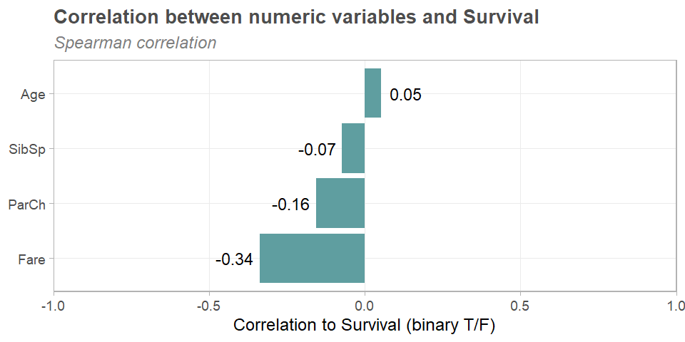

```r
df0 |> select(-PassengerId) |>
  mutate(Survived = as.integer(Survived)) |>
  correlate(method="spearman") |>
  focus(Survived) |>
  mutate(term = fct_reorder(term, Survived)) |>
  ggplot(aes(y=term, x=Survived)) +
  geom_col(fill="cadetblue") +
  geom_text(aes(x=Survived+.08*sign(Survived),label=round(Survived,2)), size=3) +
  scale_x_continuous(expand=expansion(mult=c(.0,.0)), limits=c(-1,1)) +
  labs(title="Correlation between numeric variables and Survival",
       subtitle="Spearman correlation",
       x="Correlation to Survival (binary T/F)", y=NULL)
```

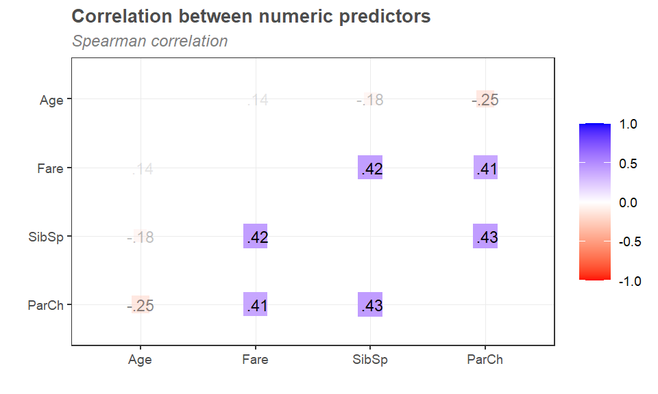

```r
df0 |> select(is.numeric, -PassengerId) |>
  correlate(method="spearman") |>
  rearrange(absolute=T) |>
  rplot(shape=15, colors=c("red", "white", "blue"), print_cor=T) +
  theme_bw(base_size=9) +
  theme(panel.grid.major = element_line(colour = "gray92", size = 0.1),
        plot.title = element_text(size = 10, colour = "gray30", face = "bold"),
        plot.subtitle = element_text(face = 'italic', colour = "gray50", size=9),
        plot.caption = element_text(colour = "gray50", hjust=0, size=8)) +
  labs(title="Correlation between numeric predictors",
       subtitle="Spearman correlation")
```

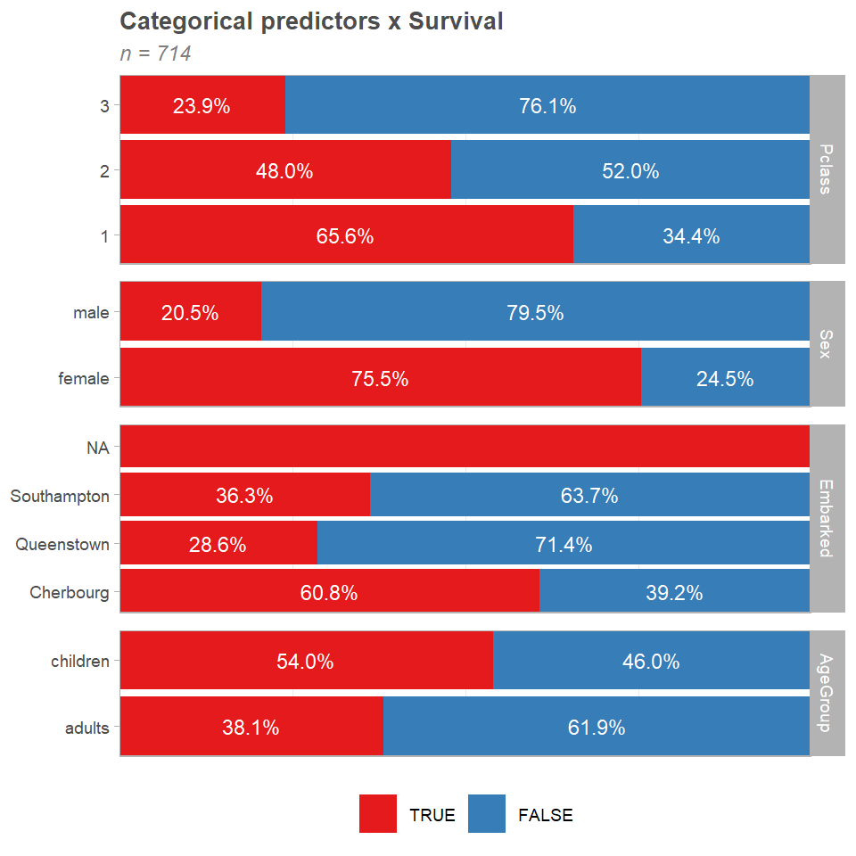

```r
ggbivariate(
  df0 |> select(is.factor),
  outcome = "Survived",
  rowbar_args = list(colour = "white",
                     size = 3,
                     label_format = scales::label_percent(accurary=1)),
  title = "Categorical predictors x Survival"
) +
  theme(panel.spacing=unit(.5, "lines"), legend.position="bottom") +
  scale_fill_brewer(palette="Set1") +
  scale_color_brewer(palette="Set1") +
  labs(subtitle=glue::glue("n = {nrow(df0)}"))
```

# 4 Preprocessing

## 4.1 Splitting

Splitting the data into training and testing sets is a critical step in the modeling process. The training set is used to fit the model and the test set is used to estimate the model’s performance on new data.

The `initial_split()` function from the `rsample` package is used to create a single split of the data. The `prop` argument specifies the proportion of the data to be allocated to the training set. The `strata` argument is used to specify a variable that should be used to stratify the data. This is useful when the outcome variable is imbalanced. (Kuhn & Johnson, 2013)

```r
set.seed(888)
df1_split <- rsample::initial_split(df0, prop=.75, strata=Survived)
df1_split
```

```
## <Training/Testing/Total>
## <535/179/714>
```

```r
df1_train <- training(df1_split)
df1_test <- testing(df1_split)

str(df1_train)
```

```
## tibble [535 × 10] (S3: tbl_df/tbl/data.frame)
##  $ PassengerId: int [1:535] 1 7 8 14 17 19 28 34 35 36 ...
##  $ Survived   : Factor w/ 2 levels "TRUE","FALSE": 2 2 2 2 2 2 2 2 2 2 ...
##  $ Pclass     : Ord.factor w/ 3 levels "1"<"2"<"3": 3 1 3 3 3 3 1 2 1 1 ...
##  $ Sex        : Factor w/ 2 levels "female","male": 2 2 2 2 2 1 2 2 2 2 ...
##  $ Age        : num [1:535] 22 54 2 39 2 31 19 66 28 42 ...
##  $ SibSp      : int [1:535] 1 0 3 1 4 1 3 0 1 1 ...
##  $ ParCh      : int [1:535] 0 0 1 5 1 0 2 0 0 0 ...
##  $ Fare       : num [1:535] 7.25 51.86 21.07 31.27 29.12 ...
##  $ Embarked   : Factor w/ 3 levels "Cherbourg","Queenstown",..: 3 3 3 3 2 3 3 3 1 3 ...
##  $ AgeGroup   : Factor w/ 2 levels "adults","children": 1 1 2 1 2 1 1 1 1 1 ...
##  - attr(*, "na.action")= 'omit' Named int [1:177] 6 18 20 27 29 30 32 33 37 43 ...
##   ..- attr(*, "names")= chr [1:177] "6" "18" "20" "27" ...
```

These objects are data frames with the same columns as the original data but only the appropriate rows for each set.

Simple random sampling is appropriate in many cases but there are exceptions. When there is a dramatic class imbalance in classification problems, one class occurs much less frequently than another. Using a simple random sample may haphazardly allocate these infrequent samples disproportionately into the training or test set. To avoid this, stratified sampling can be used. The training/test split is conducted separately within each class and then these subsamples are combined into the overall training and test set.

```r
df1_train |>
  summarise(n=n(), .by=Survived) |>
  mutate(prop = n/sum(n))
```

```
## # A tibble: 2 × 3
##   Survived     n  prop
##   <fct>    <int> <dbl>
## 1 FALSE      318 0.594
## 2 TRUE       217 0.406
```

For regression problems, the outcome data can be artificially binned into quartiles and then stratified sampling can be conducted four separate times. This is an effective method for keeping the distributions of the outcome similar between the training and test set.

## 4.2 Resampling

Chapter 3.4 “Resampling” from *Feature Engineering and Selection* (Kuhn & Johnson, 2019)  
Chapter 10 “Resampling for Evaluating Performance” from *Tidy Modeling with R* (Kuhn & Johnson, 2023)

Resampling is conducted only on the training set, as you see in Figure 4.1.

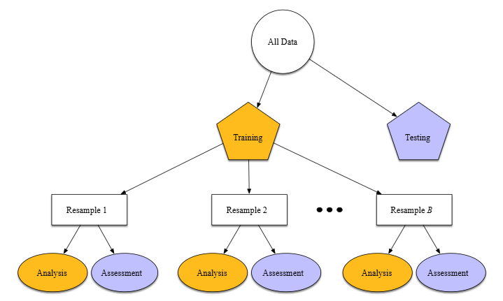

Figure 4.1: *A diagram of typical data usage with B resamples of the training data*

Before proceeding, we should be aware of what is being resampled. The *independent experimental* unit is the unit of data that is as statistically independent as possible from the other data. For example, for the Titanic data, it would be reasonable to consider each passenger to be independent of the other passengers. Since passengers are contained in rows of the data, each row is allocated to either the analysis or assessment sets. However, consider a situation where a company’s customer is the independent unit but the data set contains multiple rows per customer. In this case, each customer would be allotted to the analysis or assessment sets and all of their corresponding rows move with them.

Cross-validation is a well established resampling method. While there are a number of variations, the most common cross-validation method is **V-fold cross-validation**. Simple V-fold cross-validation creates $V$ different, randomly selected, versions of the original training set (called the folds) that have roughly equal size.

For illustration, $V = 3$ is shown in Figure 4.2 for a data set of 30 training set observations with random fold allocations. The number inside the symbols is the observation id. The color of the symbols represents their randomly assigned folds.

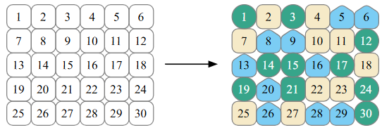

Figure 4.2: *A diagram of 3-fold cross-validation for a training set containing 30 observations*

For this hypothetical three-fold cross-validation, the three iterations of resampling are illustrated in Figure 4.3. For each resampling iteration, one fold with 10 observations is held out for assessment statistics and the remaining folds are used to train the model. Note that this ensures the assessment sets are mutually exclusive and contain different instances. This process continues for each fold so that three models produce three sets of performance statistics.

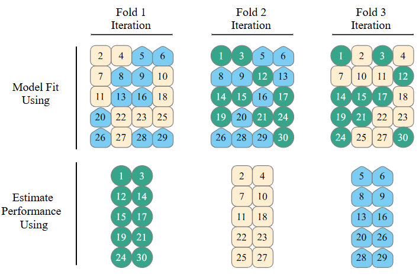

Figure 4.3: *Three iterations of the three-fold cross-validation*

Finally, a model is created on the first fold’s analysis set and the corresponding assessment set is predicted by the model. The prediction performance is summarized using the chosen measures (e.g., RMSE, the area under the ROC curve, etc.) and these statistics are saved. This process is repeated so that, in the end, there are $V$ estimates of performance for the model and each was calculated on a different assessment set. The cross-validation estimate of performance is computed by averaging the $V$ individual metrics.

When $V = 3$, the analysis sets are 2/3 of the training set and each assessment set is a distinct 1/3. The final resampling estimate of performance averages the $V$ replicates.

Using $V = 3$ is a good choice to illustrate cross-validation, but it is a poor choice in practice because it is too low to generate reliable estimates. In practice, values of $V$ are most often 5 or 10; we generally prefer 10-fold cross-validation as a default because it is large enough for good results in most situations.

What are the effects of changing $V$? Larger $V$ values result in resampling estimates with small bias but substantial variance. Smaller values of $V$ have large bias but low variance. We prefer 10-fold since noise is reduced by replication, but bias is not.

One downside to basic V-fold cross-validation is that, depending on data size or other characteristics, it may be relatively noisier (i.e., have more variability) than other resampling schemes. As with many statistical problems, one way to reduce noise is to gather more data. For cross-validation, this means averaging more than $V$ statistics.

One way to compensate for this is to conduct **repeated V-fold cross-validation**. To create $R$ repeats of V-fold cross-validation, the same fold generation process is done $R$ times to generate $R$ collections of $V$ partitions. Now, instead of averaging $V$ statistics, $V×R$ statistics are averaged to estimate performance. Due to the Central Limit Theorem, the summary statistics from each model tend toward a normal distribution, as long as we have a lot of data relative to $V×R$.

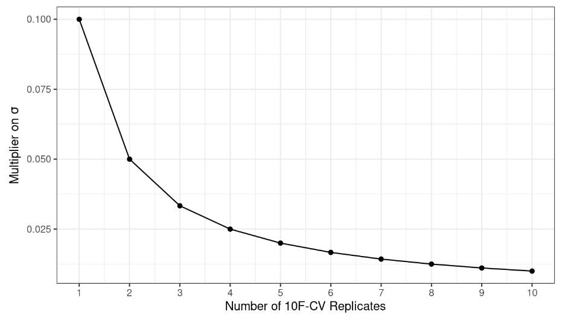

Figure 4.4: *The standard error of the mean RMSE decreases with the number of cross-validation replicates with assessment sets around 234 observations.*

Since more data are being averaged, the reduction in the variance of the final average decreases and the final average is more stable. Again, the noisiness of this procedure is relative and, as one might expect, is driven by the amount of data in the assessment set. Larger numbers of replicates tend to have less impact on the standard error. However, if the baseline value of the standard variance $\sigma$ is impractically large, the diminishing returns on replication may still be worth the extra computational costs.

One other variation, **leave-one-out cross-validation**, has $V$ equal to the size of the training set. This is a somewhat deprecated technique and may only be useful when the training set size is extremely small.

Another variant of V-fold cross-validation is **Monte Carlo cross-validation**. Like V-fold cross-validation, it allocates a fixed proportion of data to the assessment sets. The difference between MCCV and regular cross-validation is that, for MCCV, this proportion of the data is randomly selected each time. This results in assessment sets that are not mutually exclusive, i.e. some of the same data points are used in different assessment sets. This is useful when the data set is large and the computational cost of creating $V$ mutually exclusive assessment sets is prohibitive. The downside is that the assessment sets are not as independent as in V-fold cross-validation.

Other resampling techniques:

- Validation set: A single validation set is created by randomly selecting a proportion of the training set. So, when using a validation set, the initial available data set is split into a training set, a validation set, and a test set. The model is fit on the training set and evaluated on the validation set during model screening and hyper-parameter tuning. This is a simple and computationally efficient method but has high variance. It is useful when the training set is large and the model is simple.
- Bootstrapping: A bootstrap sample of the training set is a sample that is the same size as the training set but is drawn with replacement. This means that some training set data points are selected multiple times for the analysis set. Each data point has a 63.2% chance of inclusion in the training set at least once. The assessment set contains all of the training set samples that were not selected for the analysis set (on average, with 36.8% of the training set). Note that in this case the sizes of the assessment sets vary. When bootstrapping, the assessment set is often called the out-of-bag sample.

Bootstrap resampling was originally invented as a method for approximating the sampling distribution of statistics whose theoretical properties are intractable (Davison and Hinkley 1997). Using it to estimate model performance is a secondary application. Bootstrapping is useful when the data set is small and the goal is to estimate the variability of a statistic. It is also useful when the data set is large but the model is complex and the goal is to estimate the variability of the model’s performance.

Bootstrap samples produce performance estimates that have very low variance (unlike cross-validation) but have significant pessimistic bias. This means that, if the true accuracy of a model is 90%, the bootstrap would tend to estimate accuracy to be less than 90%. The amount of bias cannot be empirically determined. Additionally, the amount of bias changes over the scale of the performance metric. For example, the bias is likely to be different when the accuracy is 90% versus when it is 70%.

The bootstrap is also baked into the algorithm for many models. For example, the random forest model can contain 1,000 individual decision trees. Each tree is the product of a different bootstrap sample of the training set.

**Create resampling recipe for Titanic dataset.**

Note that when the outcome is categorical, stratified splitting techniques can be applied to make sure that the analysis and assessment sets produce the same frequency distribution of the outcome. Again, this is a good idea when a continuous outcome is skewed or a categorical outcome is imbalanced, but is unlikely to be problematic otherwise.

```r
set.seed(888)
rec_bootstrap <- bootstraps(df1_train, times=25, strata=Survived)
rec_bootstrap
```

```
## # Bootstrap sampling using stratification
## # A tibble: 25 × 2
##    splits            id
##    <list>            <chr>
##  1 <split [535/182]> Bootstrap01
##  2 <split [535/199]> Bootstrap02
##  3 <split [535/191]> Bootstrap03
##  4 <split [535/197]> Bootstrap04
##  5 <split [535/201]> Bootstrap05
##  6 <split [535/201]> Bootstrap06
##  7 <split [535/200]> Bootstrap07
##  8 <split [535/190]> Bootstrap08
##  9 <split [535/203]> Bootstrap09
## 10 <split [535/186]> Bootstrap10
## # ℹ 15 more rows
```

The resulting object is a tibble containing each of the resampling splits defined in the function arguments. It’s possible to extract the data from any one of the splits. In this case we can check, for example, the distribution of the outcome variable in the analysis set of the first split.

```r
rec_bootstrap$splits[[1]] |>
  analysis() |>
  summarise(n=n(), .by=Survived) |>
  mutate(prop = n/sum(n))
```

```
## # A tibble: 2 × 3
##   Survived     n  prop
##   <fct>    <int> <dbl>
## 1 FALSE      318 0.594
## 2 TRUE       217 0.406
```

## 4.3 Feature engineering

Chapter 8 “Feature Engineering with recipes” from *Tidy Modeling with R* (Kuhn & Johnson, 2023)  
Appendix A “Recommended preprocessing” from *Tidy Modeling with R* (Kuhn & Johnson, 2023)

Feature engineering entails reformatting predictor values to make them easier for a model to use effectively. This includes transformations and encodings of the data to best represent their important characteristics. Imagine that you have two predictors in a data set that can be more effectively represented in your model as a ratio; creating a new predictor from the ratio of the original two is a simple example of feature engineering.

Take the location of a house as a more involved example. There are a variety of ways that this spatial information can be exposed to a model, including neighborhood (a categorical measure), longitude/latitude, distance to the nearest school or university, and so on. When choosing how to encode these data in modeling, we might choose an option we believe is most associated with the outcome. The original format of the data, for example numeric (e.g., distance) versus categorical (e.g., neighborhood), is also a driving factor in feature engineering choices.

Other examples of feature engineering to build better features for modeling include:

- Correlation between predictors can be reduced via feature extraction or the removal of some predictors.
- Models that use variance-type measures may benefit from coercing the distribution of some skewed predictors to be symmetric by estimating a transformation.
- Reformatting may be required by a specific modeling technique. Some models use geometric distance metrics and, consequently, numeric predictors should be centered and scaled so that they are all in the same units. Otherwise, the distance values would be biased by the scale of each column.

Different models have different preprocessing requirements and some, such as tree-based models, require very little preprocessing at all.

A recipe is an object that defines a series of steps for data processing. Unlike making transformations directly in the formula inside a modeling function, the recipe specifies and makes explicit the steps via `step_*()` functions without immediately executing them; it is only a specification of what should be done. This way, the same recipe can be used on multiple modeling functions and the steps can be easily modified.

This is useful because the type of preprocessing needed depends on the type of model being fit. For example, models that use distance functions or dot products (neural networks, KNN, and support vector machines) should have all of their predictors on the same scale so that distance is measured appropriately, so they require predictors that have been centered and scaled. Therefore, their workflows will require recipes with these preprocessing steps.

In contrast, tree-based models (e.g., decision trees, random forests, and gradient boosting machines) do not require predictors to be centered and scaled. They can handle predictors that are on different scales and can handle missing data. Therefore, their workflows will require recipes with fewer preprocessing steps.

Figure @ref(fig:preproc_recipe) shows the baseline levels of preprocessing that are needed for various model functions. The preprocessing methods are categorized as:

- dummy: Do qualitative predictors require a numeric encoding (e.g., via dummy variables or other methods)?
- zv: Should columns with a single unique value be removed?
- impute: If some predictors are missing, should they be estimated via imputation?
- decorrelate: If there are correlated predictors, should this correlation be mitigated? This might mean filtering out predictors, using principal component analysis, or a model-based technique (e.g., regularization).
- normalize: Should predictors be centered and scaled?
- transform: Is it helpful to transform predictors to be more symmetric?

The information below is not exhaustive and may depend on the specific implementation. For example, as noted below the table, some models may not require a particular preprocessing operation but the implementation may require it. In the table, $✔$ indicates that the method is required for the model and $×$ indicates that it is not. The $◌$ symbol means that the model may be helped by the technique but it is not required.

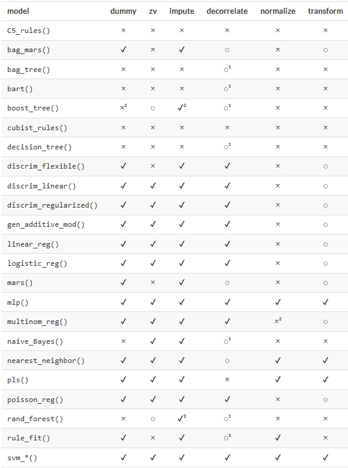

(#fig:preproc_recipe)*Baseline levels of preprocessing that are needed for various model functions.*

Footnotes:

1. Decorrelating predictors may not help improve performance. However, fewer correlated predictors can improve the estimation of variance importance scores (see [The dilution effect of random forest permutation importance scores when redundant variables are added to the model](https://bookdown.org/max/FES/recursive-feature-elimination.html#fig:greedy-rf-imp) of M. Kuhn and Johnson (2020)). Essentially, the selection of highly correlated predictors is almost random.
2. The needed preprocessing for these models depends on the implementation. Specifically: (a) Theoretically, any tree-based model does not require imputation. However, many tree ensemble implementations require imputation; (b) While tree-based boosting methods generally do not require the creation of dummy variables, models using the `xgboost` engine do.

To learn more about each of these models, and others that might be available, see https://www.tidymodels.org/find/parsnip/.

**Create recipe(s) for preprocessing the data**

```r
rec_na_omitted <- recipe(Survived ~ ., data=df1_train) |>
  update_role(PassengerId, new_role="ID") |>
  step_naomit(all_predictors(), skip=F)

rec_simple <- recipe(Survived ~ ., data=df1_train) |>
  update_role(PassengerId, new_role="ID")
```

# 5 Decision Tree

Chapter 10.3 Decision Trees from Practical Machine Learning with R (Lange 2024)

A Decision Tree machine learning model can be used for classification and regression tasks.

```r
tree_spec <-
  decision_tree(tree_depth=3) |>
  set_engine("rpart") |>
  set_mode("classification")

tree_fit <-
  workflow() |>
  add_model(tree_spec) |>
  add_recipe(rec_simple) |>
  fit(data=df1_train)

tree_fit
```

```
## ══ Workflow [trained] ══════════════════════════════════════════════════════════
## Preprocessor: Recipe
## Model: decision_tree()
##
## ── Preprocessor ────────────────────────────────────────────────────────────────
## 0 Recipe Steps
##
## ── Model ───────────────────────────────────────────────────────────────────────
## n= 535
##
## node), split, n, loss, yval, (yprob)
##       * denotes terminal node
##
##  1) root 535 217 FALSE (0.40560748 0.59439252)
##    2) Sex=female 194  43 TRUE (0.77835052 0.22164948)
##      4) Pclass=1,2 119   6 TRUE (0.94957983 0.05042017) *
##      5) Pclass=3 75  37 TRUE (0.50666667 0.49333333)
##       10) Fare< 20.8 57  21 TRUE (0.63157895 0.36842105) *
##       11) Fare>=20.8 18   2 FALSE (0.11111111 0.88888889) *
##    3) Sex=male 341  66 FALSE (0.19354839 0.80645161)
##      6) Age< 13 24   9 TRUE (0.62500000 0.37500000)
##       12) SibSp< 2 14   0 TRUE (1.00000000 0.00000000) *
##       13) SibSp>=2 10   1 FALSE (0.10000000 0.90000000) *
##      7) Age>=13 317  51 FALSE (0.16088328 0.83911672) *
```

The argument `tree_depth=3` determines that our Decision Tree has three levels or ramifications. In a real-world application the `tree_depth` might be greater than three, but it should not be too high as this can cause overfitting.

**What is a decision tree?**

A Decision Tree like the one in Figure @ref(fig:dec_tree) consists of hierarchically organized nodes (the blue and green rectangles). It can be compared to an ancestry tree. The root node on top of the tree has no ancestors but is a parent to two children. Each of these children is a parent to two other children. This process continues until it stops at the bottom of the tree. The terminal nodes at the bottom have parents but no children.

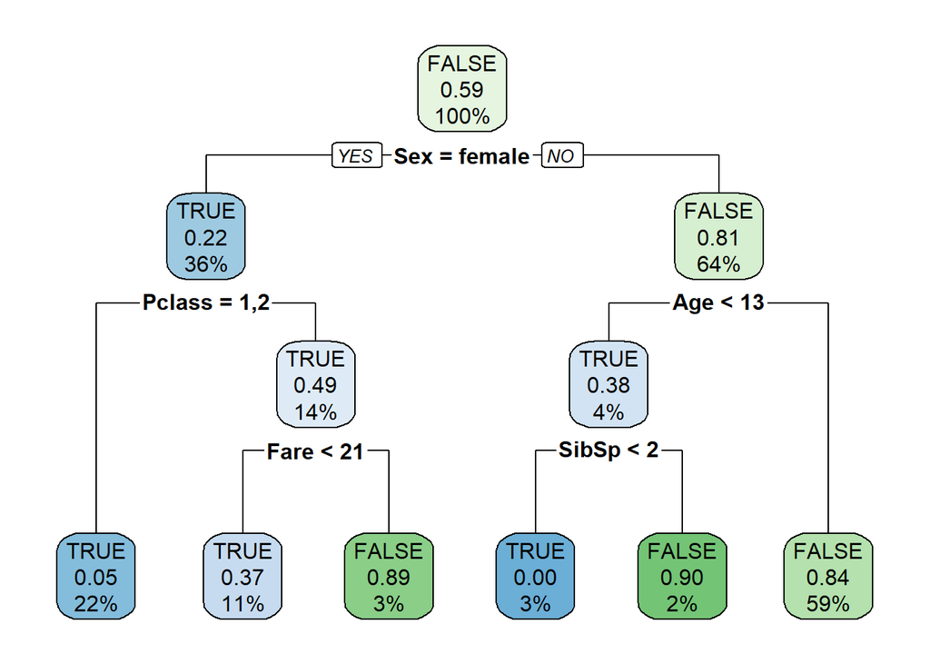

```r
# extracts the model from the workflow object and plots the decision tree
extract_fit_engine(tree_fit) |>
  rpart.plot::rpart.plot(yes.text="YES", no.text="NO", roundint=FALSE)
```

In contrast to an ancestry tree, a Decision Tree guides observations from a dataset starting at the root node to one of the terminal nodes. Decision rules are used after each parent node to determine to which of the following two child nodes an observation is moved on its way towards the terminal nodes.

After all observations from the training set descend through the tree, they end up in one of the terminal nodes. The percentages of training data in the six terminal nodes add up to 100%.

Note that not all decision rules and nodes from the Decision Tree in Figure @ref(fig:dec_tree) make sense — a major weakness of Decision Trees.

### 5.0.1 Results

From Federico Comotto’s TDS article [Evaluation metrics: leave your comfort zone and try MCC and Brier Score](https://towardsdatascience.com/evaluation-metrics-leave-your-comfort-zone-and-try-mcc-and-brier-score-86307fb1236a) on Jan 8, 2022.

Select classification and probability metrics to evaluate all models.

```r
performance_metrics <- metric_set(accuracy, roc_auc, f_meas, brier_class,
                                      sensitivity, specificity)
```

Accuracy is the proportion of correct predictions (TP + TN) among the total number of cases examined.

Precision is the proportion of correct positive predictions (TP) among the total number of positive predictions made by the model (TP + FP).

Recall is the proportion of correct positive predictions (TP) among the total number of positive samples in the test set (TP + FN).

F1 score is the harmonic mean of precision and recall. And its evolved version: Weighted F1 score, which allows the analyst to assign weights to precision and recall.

AUC stands for “Area under the ROC Curve” and it measures the area under a plot of sensitivity ($TP/(TP+FN)$), also called True Positive Rate against specificity ($TN/(TN+FP)$), also called False Positive Rate at all classification thresholds.

Brier Score determines the accuracy of a predicted probability score. BS is the mean squared error, applied to predicted probabilities.

$$BS = \frac{1}{N} \sum_{i=1}^{N} (f_i - o_i)^2$$

Use the model to make predictions on the test set.

```r
tree_test <- augment(tree_fit, new_data=df1_test)
```

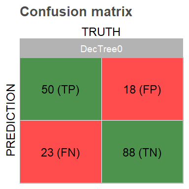

```r
df3_conf_matrix <- conf_mat(tree_test, truth=Survived, estimate=.pred_class) |>
  tidy() |>
  tidyConfMat() |>
  mutate(model="DecTree0")

plotConfMat(df3_conf_matrix)
```

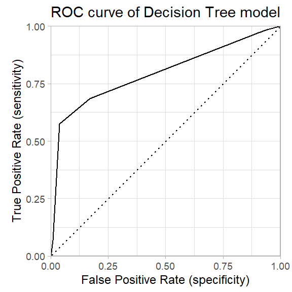

```r
tree_roc_curve <-
  tree_test |>
  roc_curve(truth=Survived, .pred_TRUE)

autoplot(tree_roc_curve, size=1.5) +
  scale_x_continuous(expand=expansion(mult=c(0,0))) +
  scale_y_continuous(expand=expansion(mult=c(0,0))) +
  theme_light(base_size=9) +
  labs(title="ROC curve of Decision Tree model",
       x="False Positive Rate (specificity)", y="True Positive Rate (sensitivity)")
```

```r
(df4_performance <- tree_test |>
    performance_metrics(truth=Survived, estimate=.pred_class, .pred_TRUE) |>
    mutate(.estimate = round(.estimate, 4),
           model="DecTree0"))
```

```
## # A tibble: 6 × 4
##   .metric     .estimator .estimate model
##   <chr>       <chr>          <dbl> <chr>
## 1 accuracy    binary         0.771 DecTree0
## 2 f_meas      binary         0.709 DecTree0
## 3 sensitivity binary         0.685 DecTree0
## 4 specificity binary         0.830 DecTree0
## 5 roc_auc     binary         0.796 DecTree0
## 6 brier_class binary         0.162 DecTree0
```

With an overall accuracy of 77%, the prediction results are not bad. The model worked particularly well in predicting passengers that did not survive (specificity = 88/(88+18) = 83%). As you can see, specificity is higher than sensitivity. However, the difference is not big enough to consider the dataset as unbalanced.

**How does the algorithm determine the decision rules?**

Decision rules are determined from the top of the Decision Tree down to the bottom. The Optimizer starts with finding the best decision rule for the root node, then moves down to the child nodes and finds the decision rule for each of the child nodes and then for the child nodes of the child nodes. The process stops when either the maximum level set with the hyper-parameter level is reached (level=3 in our case) or when splitting a node further no longer increases the predictive quality.

Decision rules of the previous level are never reversed, even if this would allow for a better decision on the current level. There is no turning back to reverse a decision rule on a previous level. This type of algorithm is called a greedy algorithm.

Decision rules have two components: The splitting variable and the splitting value, in the case of continuous variables. To find the best splitting variable and the best splitting value, the Optimizer compares all combinations of splitting variables and splitting values. The splitting variable and splitting value that result in the best split are chosen. The best split is the split that minimizes a specific pre-determined criteria.

The splitting variable and splitting value are chosen in such a way that the resulting child nodes are as pure as possible. A pure node contains only observations of the same class. The purity of a node can be measured by the Gini impurity, entropy or Information Gain. Different implementations of decision trees can use different criteria and the `rpart` engine uses Gini impurity. Gini impurity is the most common measure of node purity.

Gini impurity for an individual child node and estimates the probability that two entities taken at random from the dataset of interest (with replacement) represent different types. Mathematically, it is calculated as the product of the proportions for the observation for the two different classes ($P_{surv}$ and $P_{not\,surv}$):

$$Gini^{imp} = 2 * P_{surv} * P_{not\,surv}$$

**What are the limitations of decision trees?**

Interpreting Decision Trees is easy and straightforward. However, we have already seen that there’s no guarantee that all decision rules will necessarily make logical sense. Additionally, a decision tree is extremely sensitive to small changes in the training data.

You can see this if you run the model again with a different seed. You will notice that the predictive performance metrics will not change very much. However, the structure of the Decision Tree will be different and this makes real-life interpretation questionable.

the fact that the structure of Decision Trees reacts so sensitively to small changes is a major obstacle to use DecisionTrees for solving real-world problems. Imagine an irresponsible researcher who changes the `set.seed()` value until the structure of the Decision Tree reflects what they would like to see.

Why study Decision Trees if their interpretability is flawed and their predictive quality, although not bad, can be exceeded by other machine learning models?

The reason is that combining several Decision Trees gives us a very strong predictive quality with stability (low variance). The combination of machine learning models of the same or different types is called an ensemble. Combining many Decision Trees into one ensemble is what Random Forest and Boosting Trees models do.

# 6 Random Forest

Chapter 10.4 Random Forest from Practical Machine Learning with R (Lange 2024)

A Random Forest is an ensemble model that can be used for classification and regression tasks.

A Random Forest consists of multiple - hundreds or thousands - slightly different decision trees that produce slightly different predictions. The final prediction of the Random Forest is the aggregation of the predictions of all the decision trees. In a regression, the prediction is the mean of the predictions of all the decision trees. In a binary classification, the prediction is the class predicted by the majority of the predictions of all the decision trees. Sometimes this is called the vote of the decision trees for a given class.

In order to generate different predictions the decision trees in a random forest must be diverse. Two strategies are used to create diversity:

- **Random subspace**: Every time a new decision tree is created, a random subset of the predictors is selected. This means that each decision tree is created using a different set of predictors. The number of predictors in the random sample is a hyper-parameter of the Random Forest model. The most common default value is the square root of the number of predictors in the dataset.
- **Bootstrap (Bagging)**: Every time a new decision tree is created, a random sample of the training data is selected **with replacement** until the new training dataset has the same number of observations as the original. This means that each decision tree is created using a different set of observations.

Figure 6.1 shows the bootstrap method as it is applied in Random Forests. Each bootstrap sample will be used to generate an individual tree. Note that some observations from the training data are not included in the bootstrap sample. These observations are called out-of-bag (OOB) samples. The OOB samples are used to estimate the predictive quality of the specific decision tree. The expected number of observations in the OOB data is about 1/3 of the training data.

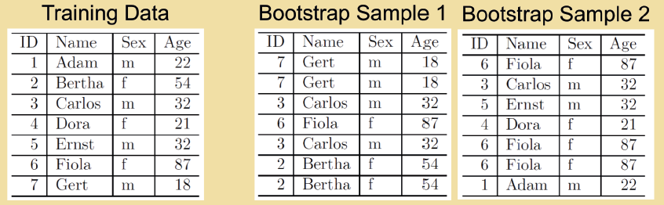

Figure 6.1: *Bootstrapping and Out-of-Bag (OOB) samples in Random Forest*

The default setting for number of `trees` in `ranger` implementation of RF is 500. However, the number of trees is a hyper-parameter and can be optimized. In contrast to the hyper-parameters `min_n` and `mtry`, a high number of `trees` in a Random Forest cannot cause overfitting. The number of trees is a trade-off between computational cost and predictive quality. The more trees, the better the predictive quality but the longer the computational time.

In this case we are using the `ranger` engine implementation of the Random Forest model. The `ranger` engine is a fast implementation of Random Forests that can handle large datasets. It uses the Gini index for classification splits as default and allows for the use of a version of the Gini index that is unbiased for the number of categories or category frequencies (`impurity_corrected`) as criteria for the assessment of variable importance (See Nembrini et al., 2018).

```r
rf_spec <-
  rand_forest(
    mtry  = 2,  # nr of predictors that will be randomly selected, defaults to sqrt(ncol(x))
    min_n = 10, # target nr of obs in node to split, defaults to 10/classification and 5/regression
    trees = 500
  ) |>
  set_engine("ranger", num.threads=parallel::detectCores(), importance="impurity_corrected") |>
  set_mode("classification")

set.seed(2021)
rf_fit <-
  workflow() |>
  add_recipe(rec_na_omitted) |>
  add_model(rf_spec) |>
  fit(df1_train)

rf_fit
```

```
## ══ Workflow [trained] ══════════════════════════════════════════════════════════
## Preprocessor: Recipe
## Model: rand_forest()
##
## ── Preprocessor ────────────────────────────────────────────────────────────────
## 1 Recipe Step
##
## • step_naomit()
##
## ── Model ───────────────────────────────────────────────────────────────────────
## Ranger result
##
## Call:
##  ranger::ranger(x = maybe_data_frame(x), y = y, mtry = min_cols(~2,      x), num.trees = ~500, min.node.size = min_rows(~10, x), num.threads = ~parallel::detectCores(),      importance = ~"impurity_corrected", verbose = FALSE, seed = sample.int(10^5,          1), probability = TRUE)
##
## Type:                             Probability estimation
## Number of trees:                  500
## Sample size:                      533
## Number of independent variables:  8
## Mtry:                             2
## Target node size:                 10
## Variable importance mode:         impurity_corrected
## Splitrule:                        gini
## OOB prediction error (Brier s.):  0.1525018
```

The performance on the OOB validation data is ok, but the real challenge is to predict the test data.

### 6.0.1 Results

Use the model to make predictions on the test set.

```r
rf_test <- augment(rf_fit, new_data=df1_test)
```

Before we get into prediction performance, though, let’s take a look at variable importance.

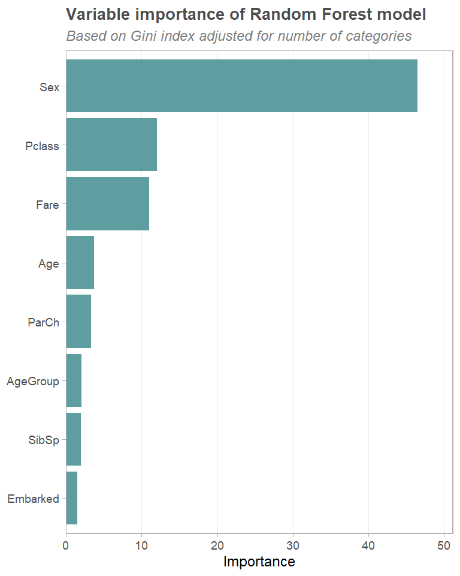

```r
rf_res_features <- ranger::importance(extract_fit_engine(rf_fit)) |> tidy() |>
  arrange(desc(x))

rf_res_features |>
  mutate(names = fct_reorder(names, x)) |>
  ggplot(aes(x=x, y=names)) +
  geom_col(fill="cadetblue") +
  scale_x_continuous(expand=expansion(mult=c(0,0.1))) +
  theme(panel.grid.major.y=element_blank()) +
  labs(title="Variable importance of Random Forest model",
       subtitle="Based on Gini index adjusted for number of categories",
       x="Importance", y=NULL)
```

In `ranger`, the impurity importance measures sums of impurity measures, while the permutation importance are the differences of prediction errors. Both are not proper units and one should be careful when comparing importance values between datasets. The `randomForest` package “scales” the importance measures by (pseudo) standard errors by default so the results are not immediately comparable. The scaled importance is biased in some cases and should be avoided (see Nicodemus et al. 2010).

Further reading:

[importance = “permutation”, what is this doing?](https://github.com/imbs-hl/ranger/issues/237)

[importance = “impurity”, what is this doing when performing regression?](https://github.com/imbs-hl/ranger/issues/489)

[What units of importance are the measures reported in?](https://github.com/imbs-hl/ranger/issues/308)

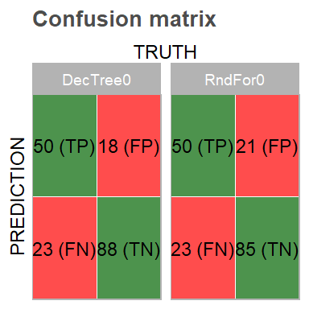

```r
df3_conf_matrix <-
  bind_rows(
    df3_conf_matrix,
    conf_mat(rf_test, truth=Survived, estimate=.pred_class) |>
      tidy() |> tidyConfMat() |>
      mutate(model="RndFor0")
  )

plotConfMat(df3_conf_matrix)
```

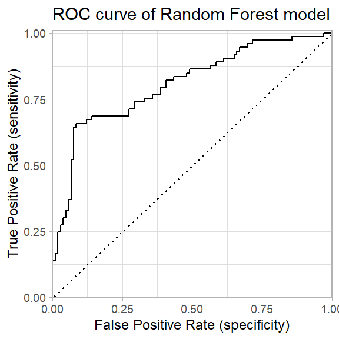

```r
rf_roc_curve <- rf_test |>
  roc_curve(truth=Survived, .pred_TRUE)

autoplot(rf_roc_curve) +
  coord_cartesian(xlim = c(0,1), ylim=c(0,1.01), expand = FALSE) +
  theme_light(base_size=9) +
  labs(title="ROC curve of Random Forest model",
       x="False Positive Rate (specificity)", y="True Positive Rate (sensitivity)")
```

```r
df4_performance <-
   bind_rows(
     df4_performance,
     rf_test |>
       performance_metrics(truth=Survived, estimate=.pred_class, .pred_TRUE) |>
       mutate(.estimate = round(.estimate, 4),
              model="RndFor0")
   )
df4_performance |> filter(model=="RndFor0")
```

```
## # A tibble: 6 × 4
##   .metric     .estimator .estimate model
##   <chr>       <chr>          <dbl> <chr>
## 1 accuracy    binary         0.754 RndFor0
## 2 f_meas      binary         0.694 RndFor0
## 3 sensitivity binary         0.685 RndFor0
## 4 specificity binary         0.802 RndFor0
## 5 roc_auc     binary         0.807 RndFor0
## 6 brier_class binary         0.177 RndFor0
```

**Compare models**

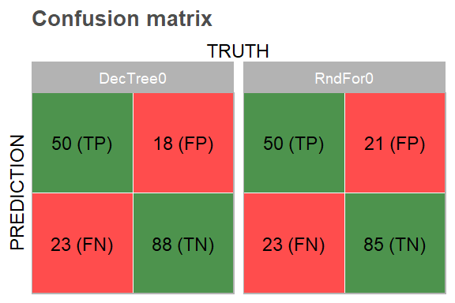

```r
plotConfMat(df3_conf_matrix)
```

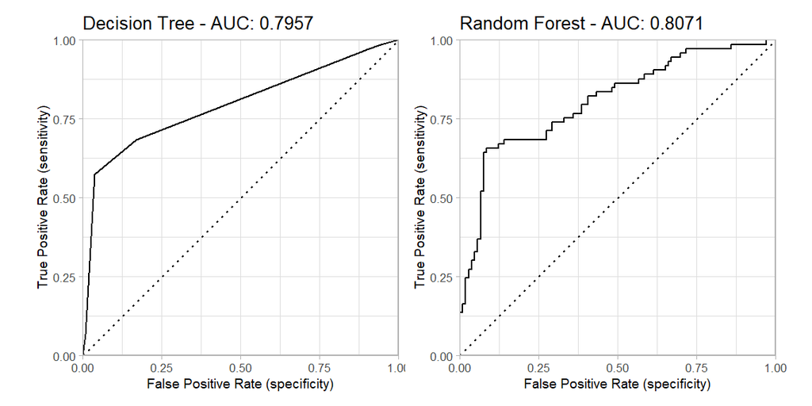

```r
p2 <- autoplot(rf_roc_curve) +
  scale_x_continuous(expand=expansion(mult=c(0,0))) +
  scale_y_continuous(expand=expansion(mult=c(0,0))) +
  labs(title=glue::glue("Random Forest - AUC: {filter(df4_performance, .metric=='roc_auc', model=='RndFor0')$.estimate}"),
       x="False Positive Rate (specificity)", y="True Positive Rate (sensitivity)")

p1 <- autoplot(tree_roc_curve) +
  scale_x_continuous(expand=expansion(mult=c(0,0))) +
  scale_y_continuous(expand=expansion(mult=c(0,0))) +
  labs(title=glue::glue("Decision Tree - AUC: {filter(df4_performance, .metric=='roc_auc', model=='DecTree0')$.estimate}"),
       x="False Positive Rate (specificity)", y="True Positive Rate (sensitivity)")

p1 + p2 &
  theme_light(base_size=8) &
  theme(axis.title = element_text(size=7))
```

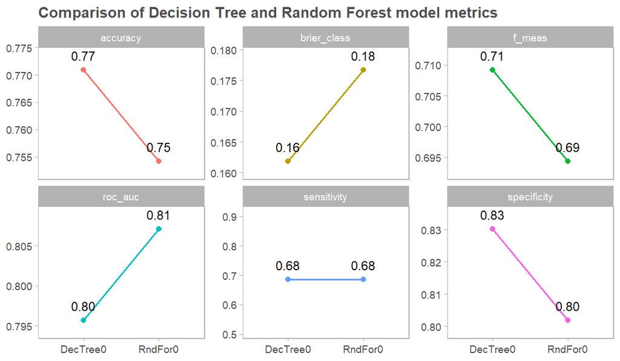

```r
df4_performance |>
  ggplot(aes(x=model, y=.estimate, group=.metric)) +
  geom_line(aes(color=.metric), linewidth=.7) + geom_point(aes(color=.metric)) +
  geom_text(aes(label=scales::number(.estimate, accuracy=.01)), vjust=-1, size=3) +
  facet_wrap(~.metric, scales="free_y", ncol=3) +
  scale_y_continuous(expand=expansion(mult=c(0.2,0.25))) +
  scale_fill_brewer(palette="Set2") +
  theme(legend.position="none",
        panel.grid.major=element_blank()) +
  labs(title="Comparison of Decision Tree and Random Forest model metrics",
       x=NULL, y=NULL)
```

# 7 Neural Network

```r
# nnet_spec <-
#   mlp(hidden_units=tune(), penalty=tune(), epochs=tune()) |>
#    set_engine("nnet", MaxNWts=2600) |>
#    set_mode("classification")
```

The analysis in M. Kuhn and Johnson (2013) specifies that the neural network should have up to 27 hidden units in the layer. The extract_parameter_set_dials() function extracts the parameter set, which we modify to have the correct parameter range:

```r
# nnet_param <- nnet_spec |>
#    extract_parameter_set_dials() |>
#    update(hidden_units = hidden_units(c(1, 27)))
```

# 8 Put it all together

Chapter 15 “Screening many models” from *Tidy Modeling with R* (Kuhn & Johnson, 2023)

**Creating a set of workflows**

Creating a set of workflows is a way to organize the modeling process. This is particularly useful when there are many models to evaluate. The `workflow_set()` function creates a tibble with a list of preprocessor and model combinations. You can combine the recipe objects with the corresponding model specifications. By default the `cross` parameter is set to `TRUE`, which makes each recipe object match with each model specification. In this case it is set to `FALSE` because decision trees don’t need missing values to be removed from the training set.

```r
wfs_0 <-
  workflow_set(
    preproc = list(recSimple = rec_simple, recNAomit = rec_na_omitted),
    models = list(tree_spec, rf_spec),
    cross=FALSE
  )

wfs_0
```

```
## # A workflow set/tibble: 2 × 4
##   wflow_id                info             option    result
##   <chr>                   <list>           <list>    <list>
## 1 recSimple_decision_tree <tibble [1 × 4]> <opts[0]> <list [0]>
## 2 recNAomit_rand_forest   <tibble [1 × 4]> <opts[0]> <list [0]>
```

Since there is only a single preprocessor for each model, `workflow_set()` creates a set with two workflows.

The `wflow_id` column is automatically created but can be modified using a call to `mutate()`.

The `option` column is a placeholder for any arguments to use when we evaluate the workflow. When a function from the `tune` or `finetune` package is used to tune (or resample) a workflow, this argument will be used.

The `result` column is a placeholder for the output of the tuning or resampling functions.

For example, to add the neural network parameter object:

```
workflow_set1 <- workflow_set1 |>
   option_add(param_info = nnet_param, id = "normalized_neural_network")

workflow_set1
#> # A workflow set/tibble: 4 × 4
#>   wflow_id                  info             option    result
#>   <chr>                     <list>           <list>    <list>
#> 1 normalized_SVM_radial     <tibble [1 × 4]> <opts[0]> <list [0]>
#> 2 normalized_SVM_poly       <tibble [1 × 4]> <opts[0]> <list [0]>
#> 3 normalized_KNN            <tibble [1 × 4]> <opts[0]> <list [0]>
#> 4 normalized_neural_network <tibble [1 × 4]> <opts[1]> <list [0]>
```

The `info` column contains a tibble with some identifiers and the workflow object.

A specific workflow can be extracted like this:

```r
wfs_0 |> extract_workflow(id = "recNAomit_rand_forest")
```

```
## ══ Workflow ════════════════════════════════════════════════════════════════════
## Preprocessor: Recipe
## Model: rand_forest()
##
## ── Preprocessor ────────────────────────────────────────────────────────────────
## 1 Recipe Step
##
## • step_naomit()
##
## ── Model ───────────────────────────────────────────────────────────────────────
## Random Forest Model Specification (classification)
##
## Main Arguments:
##   mtry = 2
##   trees = 500
##   min_n = 10
##
## Engine-Specific Arguments:
##   num.threads = parallel::detectCores()
##   importance = impurity_corrected
##
## Computational engine: ranger
```

Note that you could create another workflow set with other combinations of recipes and model specifications or different tuning parameters and combine it with the first one. The objects created are tibbles with the extra class of `workflow_set` and row binding does not affect the state of the sets and the result is itself a `workflow_set`.

## 8.1 Screening models

The `workflow_map()` function applies a given function to all of the workflows in the set; the default function is `tune_grid()`. To screen all workflows for the best model we can use the standard tuning or resampling functions (e.g., `tune_grid()` and so on). In this case, to run cross-validation resampling we can use `fit_resamples`.

```r
wfs_results <-
  workflow_map(
    wfs_0, "fit_resamples",
    resamples = rec_bootstrap,
    seed = 1503   # to ensure each execution of the function uses the same random numbers
  )
```

This will loop over all the workflows in the `workflow_set` object, applying the `fit_resamples` function to each one, using the `rec_bootstrap` cross-validation specifications. The results of each of these runs is stored under the respective model row in a new updated `workflow_set` object.

Note that the resulting object shows that the `option` and `result` columns have been updated.

```r
wfs_results
```

```
## # A workflow set/tibble: 2 × 4
##   wflow_id                info             option    result
##   <chr>                   <list>           <list>    <list>
## 1 recSimple_decision_tree <tibble [1 × 4]> <opts[1]> <rsmp[+]>
## 2 recNAomit_rand_forest   <tibble [1 × 4]> <opts[1]> <rsmp[+]>
```

The `option` column now contains any options used in the `workflow_map()` call. In the result columns, the “`tune[+]`” or “`rsmp[+]`” notations mean that the object had no issues. A value such as “`tune[x]`” or “`list[0]`” occurs if all the versions of the resampled models failed for some reason.

Note that all the results (the workflow, the model, the metrics and OOB predictions) of each iteration of resampling and tuning parameters under each model specification can be extracted for examination if needed.

The results can also be can be quickly visualized using the `autoplot()` helper function.

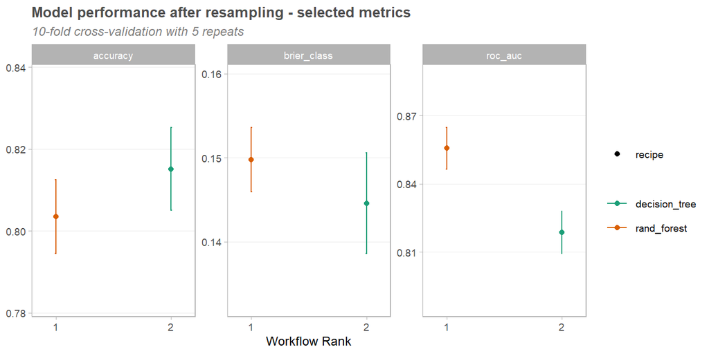

```r
autoplot(wfs_results) +
  scale_x_continuous(breaks=1:2, expand=expansion(mult=c(.2,.2))) +
  scale_y_continuous(expand=expansion(mult=c(0.5,0.5))) +
  scale_color_brewer(palette="Dark2") +
  theme(panel.grid.major.x=element_blank()) +
  labs(title="Model performance after resampling - selected metrics",
       subtitle="10-fold cross-validation with 5 repeats",
       y=NULL)
```

```r
wfs_results |>
  rank_results() |>
  filter(.metric == "roc_auc") |>
  select(model, .config, roc_auc=mean, rank)
```

```
## # A tibble: 2 × 4
##   model         .config              roc_auc  rank
##   <chr>         <chr>                  <dbl> <int>
## 1 rand_forest   Preprocessor1_Model1   0.856     1
## 2 decision_tree Preprocessor1_Model1   0.819     2
```

Also by default, `rank_results()` ranks **all** candidate sets; that’s why the same model can show up multiple times in the output. An option, called `select_best`, can be used to rank the models using their best tuning parameter combination.

Imagine we had many combinations of model specs and recipes with resampling. The `autoplot()` method plots the rankings; it also has a `select_best` argument. The plot in Figure 8.1 visualizes the best results for each model and is generated with:

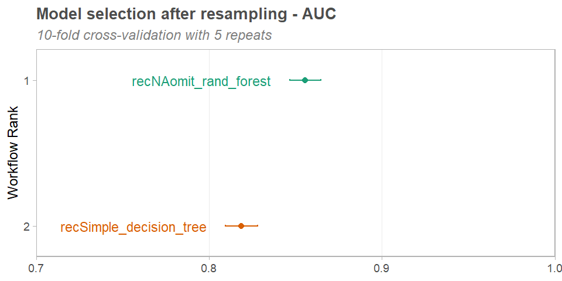

Figure 8.1: *Model selection after resampling based on AUC performance*

```r
autoplot(
  wfs_results,
  rank_metric = "roc_auc",  # <- how to order models
  metric = "roc_auc",       # <- which metric to visualize
  select_best = TRUE        # <- one model per workflow
) +
  coord_flip() +
  geom_text(aes(y=mean-.02, label=wflow_id), hjust=1, size=3) +
  scale_x_reverse(breaks=1:3, expand=expansion(mult=c(.2,.2))) +
  scale_y_continuous(expand=expansion(mult=c(0,0)), limits=c(0.7, 1)) +
  scale_color_brewer(palette="Dark2", direction=-1) +
  theme(panel.grid.major.y=element_blank()) +
  theme(legend.position = "none") +
  labs(title="Model selection after resampling - AUC",
       subtitle="10-fold cross-validation with 5 repeats",
       y=NULL)
```

```
autoplot(wfs_results, id="recNAomit_rand_forest", metric = "roc_auc")
```

There are also methods for `collect_predictions()` and `collect_metrics()`. The former collects the predictions from the resampling process and the latter collects the performance metrics. The results are stored in a tibble with a list column that contains the predictions or metrics for each resample.

The process of choosing the final model and fitting it on the training set is straightforward. The first step is to pick a workflow to finalize. The following code extracts the best model from the set, updates the parameters with the numerically best settings, and fits to the training set:

```r
wfs_fit <-
  wfs_results |>
  # Extract the workflow from the set
  extract_workflow("recNAomit_rand_forest") |>
  # Include the best results for hyper-parameters in case of tuning
  finalize_workflow(
    wfs_results |>
      extract_workflow_set_result("recNAomit_rand_forest") |>
      select_best(metric = "roc_auc")
  ) |>
  fit(df1_train)

wfs_fit
```

```
## ══ Workflow [trained] ══════════════════════════════════════════════════════════
## Preprocessor: Recipe
## Model: rand_forest()
##
## ── Preprocessor ────────────────────────────────────────────────────────────────
## 1 Recipe Step
##
## • step_naomit()
##
## ── Model ───────────────────────────────────────────────────────────────────────
## Ranger result
##
## Call:
##  ranger::ranger(x = maybe_data_frame(x), y = y, mtry = min_cols(~2,      x), num.trees = ~500, min.node.size = min_rows(~10, x), num.threads = ~parallel::detectCores(),      importance = ~"impurity_corrected", verbose = FALSE, seed = sample.int(10^5,          1), probability = TRUE)
##
## Type:                             Probability estimation
## Number of trees:                  500
## Sample size:                      533
## Number of independent variables:  8
## Mtry:                             2
## Target node size:                 10
## Variable importance mode:         impurity_corrected
## Splitrule:                        gini
## OOB prediction error (Brier s.):  0.1451756
```

We can also pick another model and finalize it.

```r
tree2_fit <-
  wfs_results |>
  extract_workflow("recSimple_decision_tree") |>
  # Include the best results for hyper-parameters in case of tuning
  finalize_workflow(
    wfs_results |>
      extract_workflow_set_result("recNAomit_rand_forest") |>
      select_best(metric = "roc_auc")
  ) |>
  fit(df1_train)

tree2_fit
```

```
## ══ Workflow [trained] ══════════════════════════════════════════════════════════
## Preprocessor: Recipe
## Model: decision_tree()
##
## ── Preprocessor ────────────────────────────────────────────────────────────────
## 0 Recipe Steps
##
## ── Model ───────────────────────────────────────────────────────────────────────
## n= 535
##
## node), split, n, loss, yval, (yprob)
##       * denotes terminal node
##
##  1) root 535 217 FALSE (0.40560748 0.59439252)
##    2) Sex=female 194  43 TRUE (0.77835052 0.22164948)
##      4) Pclass=1,2 119   6 TRUE (0.94957983 0.05042017) *
##      5) Pclass=3 75  37 TRUE (0.50666667 0.49333333)
##       10) Fare< 20.8 57  21 TRUE (0.63157895 0.36842105) *
##       11) Fare>=20.8 18   2 FALSE (0.11111111 0.88888889) *
##    3) Sex=male 341  66 FALSE (0.19354839 0.80645161)
##      6) Age< 13 24   9 TRUE (0.62500000 0.37500000)
##       12) SibSp< 2 14   0 TRUE (1.00000000 0.00000000) *
##       13) SibSp>=2 10   1 FALSE (0.10000000 0.90000000) *
##      7) Age>=13 317  51 FALSE (0.16088328 0.83911672) *
```

Next we will apply the extracted models to the test data and include the results in the comparison datasets.

```r
wfs_test <- augment(wfs_fit, new_data=df1_test)

wfs_roc_curve <- wfs_test |>
  roc_curve(truth=Survived, .pred_TRUE)

df3_conf_matrix <-
  bind_rows(
    df3_conf_matrix,
    conf_mat(wfs_test, truth=Survived, estimate=.pred_class) |>
      tidy() |>
      tidyConfMat() |>
      mutate(model="RndFor2")
  )

df4_performance <-
  bind_rows(
    df4_performance,
    wfs_test |>
      performance_metrics(truth=Survived, estimate=.pred_class, .pred_TRUE) |>
      mutate(.estimate = round(.estimate, 4)) |>
      mutate(model="RndFor2")
  )
```

```r
tree2_test <- augment(tree2_fit, new_data=df1_test)

tree2_roc_curve <- tree2_test |>
  roc_curve(truth=Survived, .pred_TRUE)

df3_conf_matrix <-
  bind_rows(
    df3_conf_matrix,
    conf_mat(tree2_test, truth=Survived, estimate=.pred_class) |>
      tidy() |>
      tidyConfMat() |>
      mutate(model="DecTree2")
  )

df4_performance <-
  bind_rows(
    df4_performance,
    tree2_test |>
      performance_metrics(truth=Survived, estimate=.pred_class, .pred_TRUE) |>
      mutate(.estimate = round(.estimate, 4)) |>
      mutate(model="DecTree2")
  )
```

# 9 Overall Results

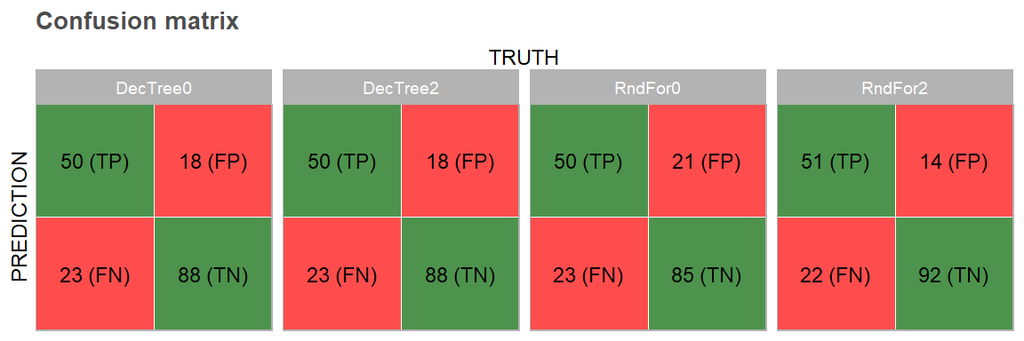

```r
plotConfMat(df3_conf_matrix)
```

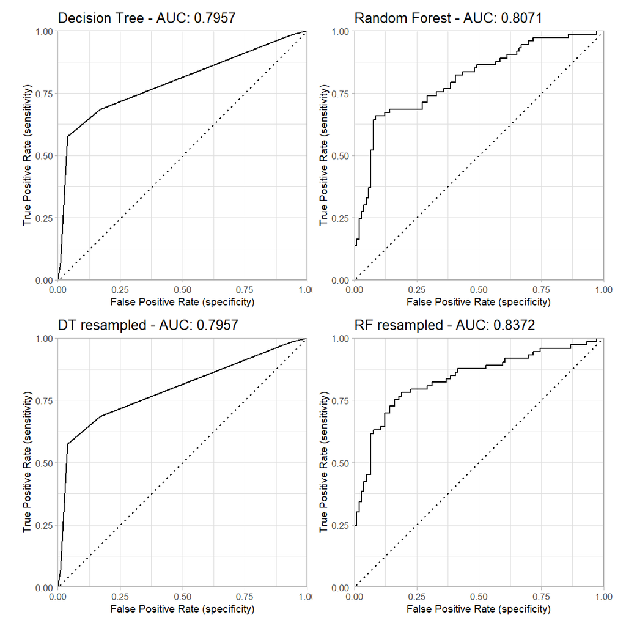

```r
p4 <- autoplot(wfs_roc_curve) +
  scale_x_continuous(expand=expansion(mult=c(0,0))) +
  scale_y_continuous(expand=expansion(mult=c(0,0))) +
  labs(title=glue::glue("RF resampled - AUC: {filter(df4_performance, .metric=='roc_auc', model=='RndFor2')$.estimate}"),
       x="False Positive Rate (specificity)", y="True Positive Rate (sensitivity)")

p3 <- autoplot(tree2_roc_curve) +
  scale_x_continuous(expand=expansion(mult=c(0,0))) +
  scale_y_continuous(expand=expansion(mult=c(0,0))) +
  labs(title=glue::glue("DT resampled - AUC: {filter(df4_performance, .metric=='roc_auc', model=='DecTree2')$.estimate}"),
       x="False Positive Rate (specificity)", y="True Positive Rate (sensitivity)")


p1 + p2 + p3 + p4 &
  theme_light(base_size=8) &
  theme(axis.title = element_text(size=7))
```

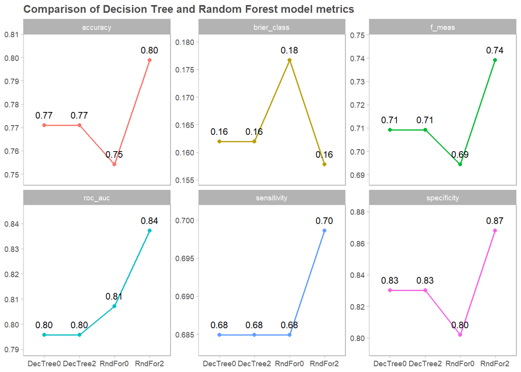

```r
df4_performance |>
  ggplot(aes(x=model, y=.estimate, group=.metric)) +
  geom_line(aes(color=.metric), linewidth=.7) + geom_point(aes(color=.metric)) +
  geom_text(aes(label=scales::number(.estimate, accuracy=.01)), vjust=-1, size=3) +
  facet_wrap(~.metric, scales="free_y", ncol=3) +
  scale_y_continuous(expand=expansion(mult=c(0.2,0.25))) +
  scale_fill_brewer(palette="Set2") +
  theme(legend.position="none",
        panel.grid.major=element_blank()) +
  labs(title="Comparison of Decision Tree and Random Forest model metrics",
       x=NULL, y=NULL)
```

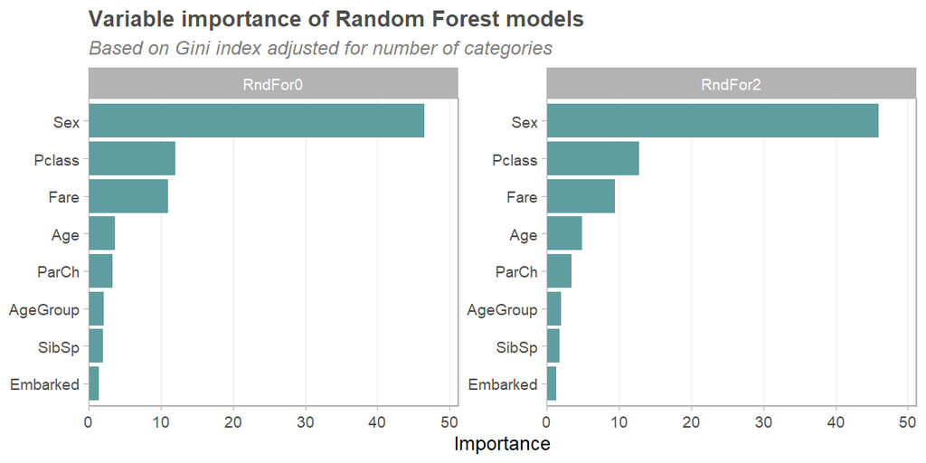

```r
df4_features <- rbind(
  rf_res_features |> mutate(model="RndFor0"),
  ranger::importance(extract_fit_engine(wfs_fit)) |> tidy() |>
    arrange(desc(x)) |>
    mutate(model="RndFor2")
)

df4_features |>
  mutate(names = fct_reorder(names, x), .by=model) |>
  ggplot(aes(x=x, y=names)) +
  geom_col(fill="cadetblue") +
  facet_wrap(~model, scales="free_y") +
  scale_x_continuous(expand=expansion(mult=c(0,0.1))) +
  theme(panel.grid.major.y=element_blank()) +
  labs(title="Variable importance of Random Forest models",
       subtitle="Based on Gini index adjusted for number of categories",
       x="Importance", y=NULL)
```

# 10 References

Davison, A, and D Hinkley. 1997. *Bootstrap Methods and Their Application*. Vol. 1. Cambridge university press.

Kuhn, M. e Johnson, K. 2013. *Applied Predictive Modeling*. Springer. ISBN 978-1-4614-6848-6. [[online](https://link.springer.com/book/10.1007/978-1-4614-6849-3)]

Kuhn, M. e Johnson, K. 2020. *Feature Engineering and Selection: A Practical Approach for Predictive Models*. Taylor & Francis Group. [[online](https://bookdown.org/max/FES/)]

Kuhn, M. e Johnson, K. 2023. *Tidy Modeling with R*. Taylor & Francis Group. [[online](https://www.tmwr.org/)]

Lange, C. 2024. *Practical Machine Learning with R: Tutorials and Case Studies (1st ed.)*. Chapman and Hall/CRC Press. DOI: 10.1201/9781003367147

Nembrini, S., Koenig, I. R. & Wright, M. N. (2018). *The revival of the Gini Importance?* Bioinformatics. DOI: [10.1093/bioinformatics/bty373](https://academic.oup.com/bioinformatics/article/34/21/3711/4994791)

Nicodemus, K.K., Malley, J.D., Strobl, C. et al. 2010. *The behaviour of random forest permutation-based variable importance measures under predictor correlation*. BMC Bioinformatics 11, 110. DOI: 10.1186/1471-2105-11-110